# Optimal Treatment Analysis

## Outcome Variable

**Outcome Variable:** ever_stunted

## Predictor Variables

**Intervention Variable:** anywast06

**Adjustment Set:**

- arm
- sex
- W_mage
- meducyrs
- month
- brthmon
- W_parity
- delta_W_mage
- delta_meducyrs
- delta_month
- delta_brthmon
- delta_W_parity

## Stratifying Variables

The analysis was stratified on these variable(s):

- agecat
- studyid
- country

## Data Summary

| agecat | studyid | country | anywast06 | ever_stunted | n_cell | n |
| --- | --- | --- | --- | --- | --- | --- |
| 0-24 months (no birth st.) | ki0047075b-MAL-ED | BANGLADESH | 0 | 0 | 76 | 217 |
| 0-24 months (no birth st.) | ki0047075b-MAL-ED | BANGLADESH | 0 | 1 | 92 | 217 |
| 0-24 months (no birth st.) | ki0047075b-MAL-ED | BANGLADESH | 1 | 0 | 28 | 217 |
| 0-24 months (no birth st.) | ki0047075b-MAL-ED | BANGLADESH | 1 | 1 | 21 | 217 |
| 0-24 months (no birth st.) | ki0047075b-MAL-ED | BRAZIL | 0 | 0 | 167 | 208 |
| 0-24 months (no birth st.) | ki0047075b-MAL-ED | BRAZIL | 0 | 1 | 27 | 208 |
| 0-24 months (no birth st.) | ki0047075b-MAL-ED | BRAZIL | 1 | 0 | 12 | 208 |
| 0-24 months (no birth st.) | ki0047075b-MAL-ED | BRAZIL | 1 | 1 | 2 | 208 |
| 0-24 months (no birth st.) | ki0047075b-MAL-ED | INDIA | 0 | 0 | 62 | 209 |
| 0-24 months (no birth st.) | ki0047075b-MAL-ED | INDIA | 0 | 1 | 82 | 209 |
| 0-24 months (no birth st.) | ki0047075b-MAL-ED | INDIA | 1 | 0 | 39 | 209 |
| 0-24 months (no birth st.) | ki0047075b-MAL-ED | INDIA | 1 | 1 | 26 | 209 |
| 0-24 months (no birth st.) | ki0047075b-MAL-ED | NEPAL | 0 | 0 | 132 | 212 |
| 0-24 months (no birth st.) | ki0047075b-MAL-ED | NEPAL | 0 | 1 | 45 | 212 |
| 0-24 months (no birth st.) | ki0047075b-MAL-ED | NEPAL | 1 | 0 | 25 | 212 |
| 0-24 months (no birth st.) | ki0047075b-MAL-ED | NEPAL | 1 | 1 | 10 | 212 |
| 0-24 months (no birth st.) | ki0047075b-MAL-ED | PERU | 0 | 0 | 112 | 266 |
| 0-24 months (no birth st.) | ki0047075b-MAL-ED | PERU | 0 | 1 | 146 | 266 |
| 0-24 months (no birth st.) | ki0047075b-MAL-ED | PERU | 1 | 0 | 3 | 266 |
| 0-24 months (no birth st.) | ki0047075b-MAL-ED | PERU | 1 | 1 | 5 | 266 |
| 0-24 months (no birth st.) | ki0047075b-MAL-ED | SOUTH AFRICA | 0 | 0 | 124 | 280 |
| 0-24 months (no birth st.) | ki0047075b-MAL-ED | SOUTH AFRICA | 0 | 1 | 127 | 280 |
| 0-24 months (no birth st.) | ki0047075b-MAL-ED | SOUTH AFRICA | 1 | 0 | 19 | 280 |
| 0-24 months (no birth st.) | ki0047075b-MAL-ED | SOUTH AFRICA | 1 | 1 | 10 | 280 |
| 0-24 months (no birth st.) | ki0047075b-MAL-ED | TANZANIA, UNITED REPUBLIC OF | 0 | 0 | 40 | 219 |
| 0-24 months (no birth st.) | ki0047075b-MAL-ED | TANZANIA, UNITED REPUBLIC OF | 0 | 1 | 170 | 219 |
| 0-24 months (no birth st.) | ki0047075b-MAL-ED | TANZANIA, UNITED REPUBLIC OF | 1 | 0 | 1 | 219 |
| 0-24 months (no birth st.) | ki0047075b-MAL-ED | TANZANIA, UNITED REPUBLIC OF | 1 | 1 | 8 | 219 |
| 0-24 months (no birth st.) | ki1000108-CMC-V-BCS-2002 | INDIA | 0 | 0 | 19 | 293 |
| 0-24 months (no birth st.) | ki1000108-CMC-V-BCS-2002 | INDIA | 0 | 1 | 118 | 293 |

[output cut: 198 more lines]

The following strata were considered:

- agecat: 0-24 months (no birth st.), studyid: ki0047075b-MAL-ED, country: BANGLADESH
- agecat: 0-24 months (no birth st.), studyid: ki0047075b-MAL-ED, country: BRAZIL
- agecat: 0-24 months (no birth st.), studyid: ki0047075b-MAL-ED, country: INDIA
- agecat: 0-24 months (no birth st.), studyid: ki0047075b-MAL-ED, country: NEPAL
- agecat: 0-24 months (no birth st.), studyid: ki0047075b-MAL-ED, country: PERU
- agecat: 0-24 months (no birth st.), studyid: ki0047075b-MAL-ED, country: SOUTH AFRICA
- agecat: 0-24 months (no birth st.), studyid: ki0047075b-MAL-ED, country: TANZANIA, UNITED REPUBLIC OF
- agecat: 0-24 months (no birth st.), studyid: ki1000108-CMC-V-BCS-2002, country: INDIA
- agecat: 0-24 months (no birth st.), studyid: ki1000108-IRC, country: INDIA
- agecat: 0-24 months (no birth st.), studyid: ki1000109-EE, country: PAKISTAN
- agecat: 0-24 months (no birth st.), studyid: ki1000109-ResPak, country: PAKISTAN
- agecat: 0-24 months (no birth st.), studyid: ki1017093b-PROVIDE, country: BANGLADESH
- agecat: 0-24 months (no birth st.), studyid: ki1066203-TanzaniaChild2, country: TANZANIA, UNITED REPUBLIC OF
- agecat: 0-24 months (no birth st.), studyid: ki1101329-Keneba, country: GAMBIA
- agecat: 0-24 months (no birth st.), studyid: ki1112895-Guatemala BSC, country: GUATEMALA
- agecat: 0-24 months (no birth st.), studyid: ki1113344-GMS-Nepal, country: NEPAL
- agecat: 0-24 months (no birth st.), studyid: ki1114097-CMIN, country: BANGLADESH
- agecat: 0-24 months (no birth st.), studyid: ki1114097-CMIN, country: PERU
- agecat: 0-24 months (no birth st.), studyid: ki1114097-CONTENT, country: PERU
- agecat: 0-6 months (no birth st.), studyid: ki0047075b-MAL-ED, country: BANGLADESH
- agecat: 0-6 months (no birth st.), studyid: ki0047075b-MAL-ED, country: BRAZIL
- agecat: 0-6 months (no birth st.), studyid: ki0047075b-MAL-ED, country: INDIA
- agecat: 0-6 months (no birth st.), studyid: ki0047075b-MAL-ED, country: NEPAL
- agecat: 0-6 months (no birth st.), studyid: ki0047075b-MAL-ED, country: PERU
- agecat: 0-6 months (no birth st.), studyid: ki0047075b-MAL-ED, country: SOUTH AFRICA
- agecat: 0-6 months (no birth st.), studyid: ki0047075b-MAL-ED, country: TANZANIA, UNITED REPUBLIC OF
- agecat: 0-6 months (no birth st.), studyid: ki1000108-CMC-V-BCS-2002, country: INDIA
- agecat: 0-6 months (no birth st.), studyid: ki1000108-IRC, country: INDIA
- agecat: 0-6 months (no birth st.), studyid: ki1000109-EE, country: PAKISTAN
- agecat: 0-6 months (no birth st.), studyid: ki1000109-ResPak, country: PAKISTAN
- agecat: 0-6 months (no birth st.), studyid: ki1017093b-PROVIDE, country: BANGLADESH
- agecat: 0-6 months (no birth st.), studyid: ki1066203-TanzaniaChild2, country: TANZANIA, UNITED REPUBLIC OF
- agecat: 0-6 months (no birth st.), studyid: ki1101329-Keneba, country: GAMBIA
- agecat: 0-6 months (no birth st.), studyid: ki1112895-Guatemala BSC, country: GUATEMALA
- agecat: 0-6 months (no birth st.), studyid: ki1113344-GMS-Nepal, country: NEPAL
- agecat: 0-6 months (no birth st.), studyid: ki1114097-CMIN, country: BANGLADESH
- agecat: 0-6 months (no birth st.), studyid: ki1114097-CMIN, country: PERU
- agecat: 0-6 months (no birth st.), studyid: ki1114097-CONTENT, country: PERU
- agecat: 6-24 months, studyid: ki0047075b-MAL-ED, country: BANGLADESH
- agecat: 6-24 months, studyid: ki0047075b-MAL-ED, country: BRAZIL
- agecat: 6-24 months, studyid: ki0047075b-MAL-ED, country: INDIA
- agecat: 6-24 months, studyid: ki0047075b-MAL-ED, country: NEPAL
- agecat: 6-24 months, studyid: ki0047075b-MAL-ED, country: PERU
- agecat: 6-24 months, studyid: ki0047075b-MAL-ED, country: SOUTH AFRICA
- agecat: 6-24 months, studyid: ki0047075b-MAL-ED, country: TANZANIA, UNITED REPUBLIC OF
- agecat: 6-24 months, studyid: ki1000108-CMC-V-BCS-2002, country: INDIA
- agecat: 6-24 months, studyid: ki1000108-IRC, country: INDIA
- agecat: 6-24 months, studyid: ki1000109-EE, country: PAKISTAN
- agecat: 6-24 months, studyid: ki1000109-ResPak, country: PAKISTAN
- agecat: 6-24 months, studyid: ki1017093b-PROVIDE, country: BANGLADESH
- agecat: 6-24 months, studyid: ki1066203-TanzaniaChild2, country: TANZANIA, UNITED REPUBLIC OF
- agecat: 6-24 months, studyid: ki1101329-Keneba, country: GAMBIA
- agecat: 6-24 months, studyid: ki1112895-Guatemala BSC, country: GUATEMALA
- agecat: 6-24 months, studyid: ki1113344-GMS-Nepal, country: NEPAL
- agecat: 6-24 months, studyid: ki1114097-CMIN, country: BANGLADESH
- agecat: 6-24 months, studyid: ki1114097-CMIN, country: PERU
- agecat: 6-24 months, studyid: ki1114097-CONTENT, country: PERU

### Dropped Strata

Some strata were dropped due to rare outcomes:

- agecat: 0-24 months (no birth st.), studyid: ki0047075b-MAL-ED, country: BRAZIL
- agecat: 0-24 months (no birth st.), studyid: ki0047075b-MAL-ED, country: PERU
- agecat: 0-24 months (no birth st.), studyid: ki0047075b-MAL-ED, country: TANZANIA, UNITED REPUBLIC OF
- agecat: 0-24 months (no birth st.), studyid: ki1112895-Guatemala BSC, country: GUATEMALA
- agecat: 0-24 months (no birth st.), studyid: ki1114097-CONTENT, country: PERU
- agecat: 0-6 months (no birth st.), studyid: ki0047075b-MAL-ED, country: BRAZIL
- agecat: 0-6 months (no birth st.), studyid: ki0047075b-MAL-ED, country: NEPAL
- agecat: 0-6 months (no birth st.), studyid: ki0047075b-MAL-ED, country: PERU
- agecat: 0-6 months (no birth st.), studyid: ki0047075b-MAL-ED, country: SOUTH AFRICA
- agecat: 0-6 months (no birth st.), studyid: ki0047075b-MAL-ED, country: TANZANIA, UNITED REPUBLIC OF
- agecat: 0-6 months (no birth st.), studyid: ki1112895-Guatemala BSC, country: GUATEMALA
- agecat: 0-6 months (no birth st.), studyid: ki1114097-CONTENT, country: PERU
- agecat: 6-24 months, studyid: ki0047075b-MAL-ED, country: BRAZIL
- agecat: 6-24 months, studyid: ki0047075b-MAL-ED, country: PERU
- agecat: 6-24 months, studyid: ki0047075b-MAL-ED, country: TANZANIA, UNITED REPUBLIC OF
- agecat: 6-24 months, studyid: ki1112895-Guatemala BSC, country: GUATEMALA
- agecat: 6-24 months, studyid: ki1114097-CONTENT, country: PERU

## Methods Detail

We’re interested in the causal parameters $E[Y_a]$ for all values of $a \in \mathcal{A}$. These parameters represent the mean outcome if, possibly contrary to fact, we intervened to set all units to have $A=a$. Under the randomization and positivity assumptions, these are identified by the statistical parameters $\psi_a=E_W[E_{Y|A,W}(Y|A=a,W)]$. In addition, we’re interested in the mean of $Y$, $E[Y]$ under no intervention (the observed mean). We will estimate these parameters by using SuperLearner to fit the relevant likelihood factors – $E_{Y|A,W}(Y|A=a,W)$ and $p(A=a|W)$, and then updating our likelihood fit using a joint TMLE.

For unadjusted analyses ($W=\{\}$), initial likelihoods were estimated using Lrnr_glm to estimate the simple $E(Y|A)$ and Lrnr_mean to estimate $p(A)$. For adjusted analyses, a small library containing Lrnr_glmnet, Lrnr_xgboost, and Lrnr_mean was used.

Having estimated these parameters, we will then use the delta method to estimate relative risks and attributable risks relative to a prespecified baseline level of $A$.

# Results Detail

## Results Plots

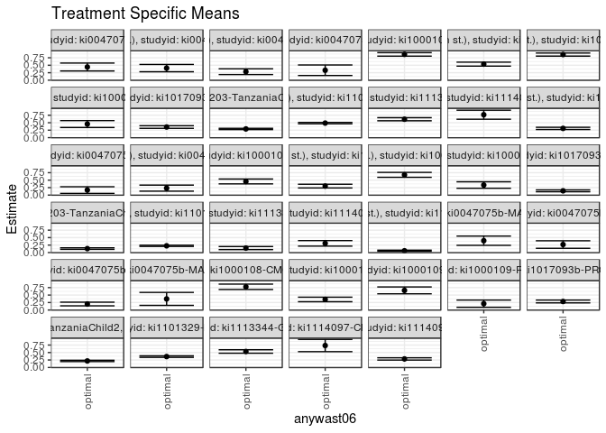

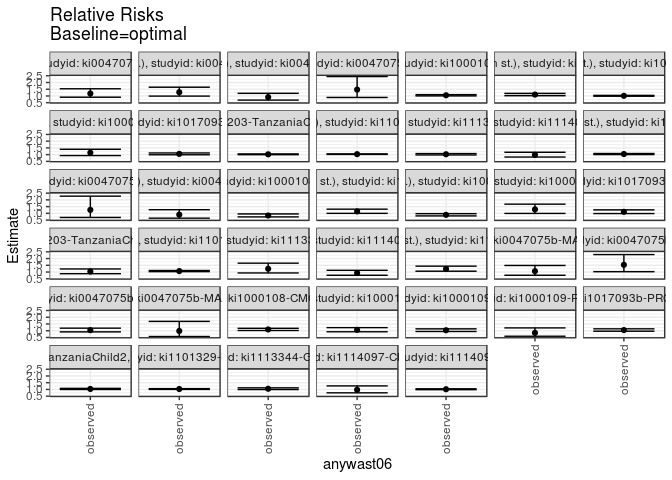

## Results Table

### Parameter: TSM

| agecat | studyid | country | intervention_level | baseline_level | estimate | ci_lower | ci_upper |
| --- | --- | --- | --- | --- | --- | --- | --- |
| 0-24 months (no birth st.) | ki0047075b-MAL-ED | BANGLADESH | optimal | NA | 0.4412995 | 0.3087077 | 0.5738912 |
| 0-24 months (no birth st.) | ki0047075b-MAL-ED | INDIA | optimal | NA | 0.4043565 | 0.2821446 | 0.5265684 |
| 0-24 months (no birth st.) | ki0047075b-MAL-ED | NEPAL | optimal | NA | 0.2848544 | 0.1891624 | 0.3805463 |
| 0-24 months (no birth st.) | ki0047075b-MAL-ED | SOUTH AFRICA | optimal | NA | 0.3325452 | 0.1566770 | 0.5084134 |
| 0-24 months (no birth st.) | ki1000108-CMC-V-BCS-2002 | INDIA | optimal | NA | 0.8635232 | 0.8055278 | 0.9215185 |
| 0-24 months (no birth st.) | ki1000108-IRC | INDIA | optimal | NA | 0.5369343 | 0.4704601 | 0.6034085 |
| 0-24 months (no birth st.) | ki1000109-EE | PAKISTAN | optimal | NA | 0.8579022 | 0.8061296 | 0.9096748 |
| 0-24 months (no birth st.) | ki1000109-ResPak | PAKISTAN | optimal | NA | 0.4548487 | 0.3393848 | 0.5703126 |
| 0-24 months (no birth st.) | ki1017093b-PROVIDE | BANGLADESH | optimal | NA | 0.3552724 | 0.3121024 | 0.3984424 |
| 0-24 months (no birth st.) | ki1066203-TanzaniaChild2 | TANZANIA, UNITED REPUBLIC OF | optimal | NA | 0.2913996 | 0.2710448 | 0.3117543 |
| 0-24 months (no birth st.) | ki1101329-Keneba | GAMBIA | optimal | NA | 0.4872290 | 0.4645879 | 0.5098700 |
| 0-24 months (no birth st.) | ki1113344-GMS-Nepal | NEPAL | optimal | NA | 0.6162987 | 0.5649963 | 0.6676011 |
| 0-24 months (no birth st.) | ki1114097-CMIN | BANGLADESH | optimal | NA | 0.7675396 | 0.6161346 | 0.9189446 |
| 0-24 months (no birth st.) | ki1114097-CMIN | PERU | optimal | NA | 0.3096974 | 0.2730803 | 0.3463145 |
| 0-6 months (no birth st.) | ki0047075b-MAL-ED | BANGLADESH | optimal | NA | 0.1687540 | 0.0578789 | 0.2796292 |
| 0-6 months (no birth st.) | ki0047075b-MAL-ED | INDIA | optimal | NA | 0.2330328 | 0.1318524 | 0.3342131 |
| 0-6 months (no birth st.) | ki1000108-CMC-V-BCS-2002 | INDIA | optimal | NA | 0.4569116 | 0.3761890 | 0.5376343 |
| 0-6 months (no birth st.) | ki1000108-IRC | INDIA | optimal | NA | 0.3014257 | 0.2389976 | 0.3638539 |
| 0-6 months (no birth st.) | ki1000109-EE | PAKISTAN | optimal | NA | 0.6775141 | 0.5948886 | 0.7601395 |
| 0-6 months (no birth st.) | ki1000109-ResPak | PAKISTAN | optimal | NA | 0.3370388 | 0.2291371 | 0.4449406 |
| 0-6 months (no birth st.) | ki1017093b-PROVIDE | BANGLADESH | optimal | NA | 0.1431674 | 0.1116607 | 0.1746742 |
| 0-6 months (no birth st.) | ki1066203-TanzaniaChild2 | TANZANIA, UNITED REPUBLIC OF | optimal | NA | 0.1320731 | 0.1061805 | 0.1579656 |
| 0-6 months (no birth st.) | ki1101329-Keneba | GAMBIA | optimal | NA | 0.2254981 | 0.2065092 | 0.2444869 |
| 0-6 months (no birth st.) | ki1113344-GMS-Nepal | NEPAL | optimal | NA | 0.1504012 | 0.0999726 | 0.2008297 |
| 0-6 months (no birth st.) | ki1114097-CMIN | BANGLADESH | optimal | NA | 0.3082414 | 0.2154450 | 0.4010379 |
| 0-6 months (no birth st.) | ki1114097-CMIN | PERU | optimal | NA | 0.0603584 | 0.0414903 | 0.0792265 |
| 6-24 months | ki0047075b-MAL-ED | BANGLADESH | optimal | NA | 0.3964993 | 0.2419128 | 0.5510859 |
| 6-24 months | ki0047075b-MAL-ED | INDIA | optimal | NA | 0.2688629 | 0.1436628 | 0.3940631 |
| 6-24 months | ki0047075b-MAL-ED | NEPAL | optimal | NA | 0.2014139 | 0.1398116 | 0.2630163 |
| 6-24 months | ki0047075b-MAL-ED | SOUTH AFRICA | optimal | NA | 0.3713825 | 0.1544670 | 0.5882979 |
| 6-24 months | ki1000108-CMC-V-BCS-2002 | INDIA | optimal | NA | 0.7768197 | 0.6876066 | 0.8660328 |
| 6-24 months | ki1000108-IRC | INDIA | optimal | NA | 0.3539699 | 0.2778693 | 0.4300705 |
| 6-24 months | ki1000109-EE | PAKISTAN | optimal | NA | 0.6566620 | 0.5418221 | 0.7715019 |
| 6-24 months | ki1000109-ResPak | PAKISTAN | optimal | NA | 0.2115529 | 0.0900997 | 0.3330062 |
| 6-24 months | ki1017093b-PROVIDE | BANGLADESH | optimal | NA | 0.2858027 | 0.2382893 | 0.3333161 |
| 6-24 months | ki1066203-TanzaniaChild2 | TANZANIA, UNITED REPUBLIC OF | optimal | NA | 0.2184951 | 0.1965660 | 0.2404243 |
| 6-24 months | ki1101329-Keneba | GAMBIA | optimal | NA | 0.3646915 | 0.3389234 | 0.3904595 |
| 6-24 months | ki1113344-GMS-Nepal | NEPAL | optimal | NA | 0.5345440 | 0.4769024 | 0.5921857 |
| 6-24 months | ki1114097-CMIN | BANGLADESH | optimal | NA | 0.7339759 | 0.5289012 | 0.9390507 |
| 6-24 months | ki1114097-CMIN | PERU | optimal | NA | 0.2854081 | 0.2471307 | 0.3236855 |

### Parameter: E(Y)

| agecat | studyid | country | intervention_level | baseline_level | estimate | ci_lower | ci_upper |
| --- | --- | --- | --- | --- | --- | --- | --- |
| 0-24 months (no birth st.) | ki0047075b-MAL-ED | BANGLADESH | observed | NA | 0.5207373 | 0.4541154 | 0.5873593 |
| 0-24 months (no birth st.) | ki0047075b-MAL-ED | INDIA | observed | NA | 0.5167464 | 0.4488350 | 0.5846578 |
| 0-24 months (no birth st.) | ki0047075b-MAL-ED | NEPAL | observed | NA | 0.2594340 | 0.2002911 | 0.3185768 |
| 0-24 months (no birth st.) | ki0047075b-MAL-ED | SOUTH AFRICA | observed | NA | 0.4892857 | 0.4306292 | 0.5479422 |
| 0-24 months (no birth st.) | ki1000108-CMC-V-BCS-2002 | INDIA | observed | NA | 0.9078498 | 0.8746748 | 0.9410249 |
| 0-24 months (no birth st.) | ki1000108-IRC | INDIA | observed | NA | 0.5916667 | 0.5408218 | 0.6425115 |
| 0-24 months (no birth st.) | ki1000109-EE | PAKISTAN | observed | NA | 0.8674699 | 0.8252704 | 0.9096693 |
| 0-24 months (no birth st.) | ki1000109-ResPak | PAKISTAN | observed | NA | 0.5198020 | 0.4507336 | 0.5888704 |
| 0-24 months (no birth st.) | ki1017093b-PROVIDE | BANGLADESH | observed | NA | 0.3753943 | 0.3376725 | 0.4131162 |
| 0-24 months (no birth st.) | ki1066203-TanzaniaChild2 | TANZANIA, UNITED REPUBLIC OF | observed | NA | 0.2988814 | 0.2798990 | 0.3178639 |
| 0-24 months (no birth st.) | ki1101329-Keneba | GAMBIA | observed | NA | 0.5044763 | 0.4837388 | 0.5252138 |
| 0-24 months (no birth st.) | ki1113344-GMS-Nepal | NEPAL | observed | NA | 0.6336449 | 0.5927799 | 0.6745099 |
| 0-24 months (no birth st.) | ki1114097-CMIN | BANGLADESH | observed | NA | 0.7559524 | 0.6908084 | 0.8210964 |
| 0-24 months (no birth st.) | ki1114097-CMIN | PERU | observed | NA | 0.3237082 | 0.2879308 | 0.3594857 |
| 0-6 months (no birth st.) | ki0047075b-MAL-ED | BANGLADESH | observed | NA | 0.2119816 | 0.1574763 | 0.2664868 |
| 0-6 months (no birth st.) | ki0047075b-MAL-ED | INDIA | observed | NA | 0.2105263 | 0.1551227 | 0.2659300 |
| 0-6 months (no birth st.) | ki1000108-CMC-V-BCS-2002 | INDIA | observed | NA | 0.3835616 | 0.3276935 | 0.4394298 |
| 0-6 months (no birth st.) | ki1000108-IRC | INDIA | observed | NA | 0.3444444 | 0.2952897 | 0.3935992 |
| 0-6 months (no birth st.) | ki1000109-EE | PAKISTAN | observed | NA | 0.6024096 | 0.5415000 | 0.6633193 |
| 0-6 months (no birth st.) | ki1000109-ResPak | PAKISTAN | observed | NA | 0.4356436 | 0.3670959 | 0.5041912 |
| 0-6 months (no birth st.) | ki1017093b-PROVIDE | BANGLADESH | observed | NA | 0.1593060 | 0.1307970 | 0.1878149 |
| 0-6 months (no birth st.) | ki1066203-TanzaniaChild2 | TANZANIA, UNITED REPUBLIC OF | observed | NA | 0.1369128 | 0.1226581 | 0.1511674 |
| 0-6 months (no birth st.) | ki1101329-Keneba | GAMBIA | observed | NA | 0.2412713 | 0.2235253 | 0.2590172 |
| 0-6 months (no birth st.) | ki1113344-GMS-Nepal | NEPAL | observed | NA | 0.1869159 | 0.1538509 | 0.2199809 |
| 0-6 months (no birth st.) | ki1114097-CMIN | BANGLADESH | observed | NA | 0.2857143 | 0.2171983 | 0.3542303 |
| 0-6 months (no birth st.) | ki1114097-CMIN | PERU | observed | NA | 0.0744681 | 0.0543935 | 0.0945427 |
| 6-24 months | ki0047075b-MAL-ED | BANGLADESH | observed | NA | 0.4213836 | 0.3443902 | 0.4983771 |
| 6-24 months | ki0047075b-MAL-ED | INDIA | observed | NA | 0.4129032 | 0.3351414 | 0.4906651 |
| 6-24 months | ki0047075b-MAL-ED | NEPAL | observed | NA | 0.2102564 | 0.1529155 | 0.2675974 |
| 6-24 months | ki0047075b-MAL-ED | SOUTH AFRICA | observed | NA | 0.3647799 | 0.2897219 | 0.4398379 |
| 6-24 months | ki1000108-CMC-V-BCS-2002 | INDIA | observed | NA | 0.8508287 | 0.7987841 | 0.9028733 |
| 6-24 months | ki1000108-IRC | INDIA | observed | NA | 0.3771186 | 0.3151523 | 0.4390850 |
| 6-24 months | ki1000109-EE | PAKISTAN | observed | NA | 0.6804124 | 0.5871313 | 0.7736934 |
| 6-24 months | ki1000109-ResPak | PAKISTAN | observed | NA | 0.1789474 | 0.1014597 | 0.2564350 |
| 6-24 months | ki1017093b-PROVIDE | BANGLADESH | observed | NA | 0.2997812 | 0.2577294 | 0.3418330 |
| 6-24 months | ki1066203-TanzaniaChild2 | TANZANIA, UNITED REPUBLIC OF | observed | NA | 0.2259675 | 0.2054816 | 0.2464534 |
| 6-24 months | ki1101329-Keneba | GAMBIA | observed | NA | 0.3752393 | 0.3512585 | 0.3992201 |
| 6-24 months | ki1113344-GMS-Nepal | NEPAL | observed | NA | 0.5610329 | 0.5138522 | 0.6082135 |
| 6-24 months | ki1114097-CMIN | BANGLADESH | observed | NA | 0.7117117 | 0.6270636 | 0.7963598 |
| 6-24 months | ki1114097-CMIN | PERU | observed | NA | 0.2892416 | 0.2518881 | 0.3265951 |

### Parameter: RR

| agecat | studyid | country | intervention_level | baseline_level | estimate | ci_lower | ci_upper |
| --- | --- | --- | --- | --- | --- | --- | --- |
| 0-24 months (no birth st.) | ki0047075b-MAL-ED | BANGLADESH | observed | optimal | 1.1800090 | 0.9073491 | 1.5346037 |
| 0-24 months (no birth st.) | ki0047075b-MAL-ED | INDIA | observed | optimal | 1.2779476 | 0.9896534 | 1.6502242 |
| 0-24 months (no birth st.) | ki0047075b-MAL-ED | NEPAL | observed | optimal | 0.9107600 | 0.6941035 | 1.1950435 |
| 0-24 months (no birth st.) | ki0047075b-MAL-ED | SOUTH AFRICA | observed | optimal | 1.4713359 | 0.8874243 | 2.4394524 |
| 0-24 months (no birth st.) | ki1000108-CMC-V-BCS-2002 | INDIA | observed | optimal | 1.0513323 | 1.0072792 | 1.0973121 |
| 0-24 months (no birth st.) | ki1000108-IRC | INDIA | observed | optimal | 1.1019348 | 1.0210014 | 1.1892837 |
| 0-24 months (no birth st.) | ki1000109-EE | PAKISTAN | observed | optimal | 1.0111524 | 0.9807705 | 1.0424755 |
| 0-24 months (no birth st.) | ki1000109-ResPak | PAKISTAN | observed | optimal | 1.1428019 | 0.9329024 | 1.3999280 |
| 0-24 months (no birth st.) | ki1017093b-PROVIDE | BANGLADESH | observed | optimal | 1.0566380 | 0.9918349 | 1.1256752 |
| 0-24 months (no birth st.) | ki1066203-TanzaniaChild2 | TANZANIA, UNITED REPUBLIC OF | observed | optimal | 1.0256756 | 0.9977844 | 1.0543466 |
| 0-24 months (no birth st.) | ki1101329-Keneba | GAMBIA | observed | optimal | 1.0353987 | 1.0160606 | 1.0551049 |
| 0-24 months (no birth st.) | ki1113344-GMS-Nepal | NEPAL | observed | optimal | 1.0281457 | 0.9778413 | 1.0810380 |
| 0-24 months (no birth st.) | ki1114097-CMIN | BANGLADESH | observed | optimal | 0.9849034 | 0.8241409 | 1.1770254 |
| 0-24 months (no birth st.) | ki1114097-CMIN | PERU | observed | optimal | 1.0452403 | 1.0090899 | 1.0826858 |
| 0-6 months (no birth st.) | ki0047075b-MAL-ED | BANGLADESH | observed | optimal | 1.2561572 | 0.6931446 | 2.2764815 |
| 0-6 months (no birth st.) | ki0047075b-MAL-ED | INDIA | observed | optimal | 0.9034194 | 0.6425135 | 1.2702716 |
| 0-6 months (no birth st.) | ki1000108-CMC-V-BCS-2002 | INDIA | observed | optimal | 0.8394657 | 0.7373222 | 0.9557595 |
| 0-6 months (no birth st.) | ki1000108-IRC | INDIA | observed | optimal | 1.1427174 | 0.9966909 | 1.3101385 |
| 0-6 months (no birth st.) | ki1000109-EE | PAKISTAN | observed | optimal | 0.8891471 | 0.8106444 | 0.9752520 |
| 0-6 months (no birth st.) | ki1000109-ResPak | PAKISTAN | observed | optimal | 1.2925619 | 0.9939915 | 1.6808154 |
| 0-6 months (no birth st.) | ki1017093b-PROVIDE | BANGLADESH | observed | optimal | 1.1127252 | 0.9839337 | 1.2583748 |
| 0-6 months (no birth st.) | ki1066203-TanzaniaChild2 | TANZANIA, UNITED REPUBLIC OF | observed | optimal | 1.0366440 | 0.8763470 | 1.2262616 |
| 0-6 months (no birth st.) | ki1101329-Keneba | GAMBIA | observed | optimal | 1.0699482 | 1.0298361 | 1.1116226 |
| 0-6 months (no birth st.) | ki1113344-GMS-Nepal | NEPAL | observed | optimal | 1.2427823 | 0.9305391 | 1.6597989 |
| 0-6 months (no birth st.) | ki1114097-CMIN | BANGLADESH | observed | optimal | 0.9269172 | 0.7603925 | 1.1299105 |
| 0-6 months (no birth st.) | ki1114097-CMIN | PERU | observed | optimal | 1.2337658 | 1.0611898 | 1.4344068 |
| 6-24 months | ki0047075b-MAL-ED | BANGLADESH | observed | optimal | 1.0627600 | 0.7589180 | 1.4882488 |
| 6-24 months | ki0047075b-MAL-ED | INDIA | observed | optimal | 1.5357387 | 1.0269039 | 2.2967031 |
| 6-24 months | ki0047075b-MAL-ED | NEPAL | observed | optimal | 1.0439019 | 0.9146224 | 1.1914548 |
| 6-24 months | ki0047075b-MAL-ED | SOUTH AFRICA | observed | optimal | 0.9822216 | 0.5700586 | 1.6923862 |
| 6-24 months | ki1000108-CMC-V-BCS-2002 | INDIA | observed | optimal | 1.0952718 | 1.0158618 | 1.1808894 |
| 6-24 months | ki1000108-IRC | INDIA | observed | optimal | 1.0653975 | 0.9241095 | 1.2282871 |
| 6-24 months | ki1000109-EE | PAKISTAN | observed | optimal | 1.0361684 | 0.9439378 | 1.1374106 |
| 6-24 months | ki1000109-ResPak | PAKISTAN | observed | optimal | 0.8458751 | 0.5911571 | 1.2103461 |
| 6-24 months | ki1017093b-PROVIDE | BANGLADESH | observed | optimal | 1.0489096 | 0.9640224 | 1.1412716 |
| 6-24 months | ki1066203-TanzaniaChild2 | TANZANIA, UNITED REPUBLIC OF | observed | optimal | 1.0341993 | 0.9924205 | 1.0777370 |
| 6-24 months | ki1101329-Keneba | GAMBIA | observed | optimal | 1.0289227 | 1.0003948 | 1.0582641 |
| 6-24 months | ki1113344-GMS-Nepal | NEPAL | observed | optimal | 1.0495540 | 0.9880555 | 1.1148804 |
| 6-24 months | ki1114097-CMIN | BANGLADESH | observed | optimal | 0.9696663 | 0.7455152 | 1.2612120 |
| 6-24 months | ki1114097-CMIN | PERU | observed | optimal | 1.0134316 | 0.9799700 | 1.0480358 |

### Parameter: PAR

| agecat | studyid | country | intervention_level | baseline_level | estimate | ci_lower | ci_upper |
| --- | --- | --- | --- | --- | --- | --- | --- |
| 0-24 months (no birth st.) | ki0047075b-MAL-ED | BANGLADESH | optimal | NA | 0.0794379 | -0.0362226 | 0.1950983 |
| 0-24 months (no birth st.) | ki0047075b-MAL-ED | INDIA | optimal | NA | 0.1123899 | 0.0098781 | 0.2149017 |
| 0-24 months (no birth st.) | ki0047075b-MAL-ED | NEPAL | optimal | NA | -0.0254204 | -0.1024151 | 0.0515743 |
| 0-24 months (no birth st.) | ki0047075b-MAL-ED | SOUTH AFRICA | optimal | NA | 0.1567405 | -0.0109440 | 0.3244250 |
| 0-24 months (no birth st.) | ki1000108-CMC-V-BCS-2002 | INDIA | optimal | NA | 0.0443266 | 0.0080290 | 0.0806243 |
| 0-24 months (no birth st.) | ki1000108-IRC | INDIA | optimal | NA | 0.0547323 | 0.0142676 | 0.0951970 |
| 0-24 months (no birth st.) | ki1000109-EE | PAKISTAN | optimal | NA | 0.0095677 | -0.0165548 | 0.0356902 |
| 0-24 months (no birth st.) | ki1000109-ResPak | PAKISTAN | optimal | NA | 0.0649533 | -0.0268585 | 0.1567650 |
| 0-24 months (no birth st.) | ki1017093b-PROVIDE | BANGLADESH | optimal | NA | 0.0201219 | -0.0023492 | 0.0425931 |
| 0-24 months (no birth st.) | ki1066203-TanzaniaChild2 | TANZANIA, UNITED REPUBLIC OF | optimal | NA | 0.0074819 | -0.0005544 | 0.0155181 |
| 0-24 months (no birth st.) | ki1101329-Keneba | GAMBIA | optimal | NA | 0.0172473 | 0.0080861 | 0.0264084 |
| 0-24 months (no birth st.) | ki1113344-GMS-Nepal | NEPAL | optimal | NA | 0.0173462 | -0.0135467 | 0.0482390 |
| 0-24 months (no birth st.) | ki1114097-CMIN | BANGLADESH | optimal | NA | -0.0115872 | -0.1483592 | 0.1251848 |
| 0-24 months (no birth st.) | ki1114097-CMIN | PERU | optimal | NA | 0.0140108 | 0.0031046 | 0.0249170 |
| 0-6 months (no birth st.) | ki0047075b-MAL-ED | BANGLADESH | optimal | NA | 0.0432276 | -0.0572867 | 0.1437418 |
| 0-6 months (no birth st.) | ki0047075b-MAL-ED | INDIA | optimal | NA | -0.0225064 | -0.1022470 | 0.0572341 |
| 0-6 months (no birth st.) | ki1000108-CMC-V-BCS-2002 | INDIA | optimal | NA | -0.0733500 | -0.1316523 | -0.0150477 |
| 0-6 months (no birth st.) | ki1000108-IRC | INDIA | optimal | NA | 0.0430187 | 0.0019531 | 0.0840843 |
| 0-6 months (no birth st.) | ki1000109-EE | PAKISTAN | optimal | NA | -0.0751044 | -0.1365972 | -0.0136116 |
| 0-6 months (no birth st.) | ki1000109-ResPak | PAKISTAN | optimal | NA | 0.0986047 | 0.0103635 | 0.1868459 |
| 0-6 months (no birth st.) | ki1017093b-PROVIDE | BANGLADESH | optimal | NA | 0.0161386 | -0.0016249 | 0.0339021 |
| 0-6 months (no birth st.) | ki1066203-TanzaniaChild2 | TANZANIA, UNITED REPUBLIC OF | optimal | NA | 0.0048397 | -0.0173609 | 0.0270402 |
| 0-6 months (no birth st.) | ki1101329-Keneba | GAMBIA | optimal | NA | 0.0157732 | 0.0071244 | 0.0244220 |
| 0-6 months (no birth st.) | ki1113344-GMS-Nepal | NEPAL | optimal | NA | 0.0365147 | -0.0076411 | 0.0806706 |
| 0-6 months (no birth st.) | ki1114097-CMIN | BANGLADESH | optimal | NA | -0.0225272 | -0.0834606 | 0.0384063 |
| 0-6 months (no birth st.) | ki1114097-CMIN | PERU | optimal | NA | 0.0141097 | 0.0043534 | 0.0238660 |
| 6-24 months | ki0047075b-MAL-ED | BANGLADESH | optimal | NA | 0.0248843 | -0.1085133 | 0.1582819 |
| 6-24 months | ki0047075b-MAL-ED | INDIA | optimal | NA | 0.1440403 | 0.0359041 | 0.2521765 |
| 6-24 months | ki0047075b-MAL-ED | NEPAL | optimal | NA | 0.0088425 | -0.0178390 | 0.0355240 |
| 6-24 months | ki0047075b-MAL-ED | SOUTH AFRICA | optimal | NA | -0.0066026 | -0.2086850 | 0.1954798 |
| 6-24 months | ki1000108-CMC-V-BCS-2002 | INDIA | optimal | NA | 0.0740090 | 0.0172509 | 0.1307671 |
| 6-24 months | ki1000108-IRC | INDIA | optimal | NA | 0.0231487 | -0.0274376 | 0.0737351 |
| 6-24 months | ki1000109-EE | PAKISTAN | optimal | NA | 0.0237504 | -0.0371578 | 0.0846586 |
| 6-24 months | ki1000109-ResPak | PAKISTAN | optimal | NA | -0.0326056 | -0.1103178 | 0.0451067 |
| 6-24 months | ki1017093b-PROVIDE | BANGLADESH | optimal | NA | 0.0139785 | -0.0101512 | 0.0381082 |
| 6-24 months | ki1066203-TanzaniaChild2 | TANZANIA, UNITED REPUBLIC OF | optimal | NA | 0.0074724 | -0.0015490 | 0.0164938 |
| 6-24 months | ki1101329-Keneba | GAMBIA | optimal | NA | 0.0105479 | 0.0002935 | 0.0208022 |
| 6-24 months | ki1113344-GMS-Nepal | NEPAL | optimal | NA | 0.0264888 | -0.0056650 | 0.0586426 |
| 6-24 months | ki1114097-CMIN | BANGLADESH | optimal | NA | -0.0222642 | -0.2150078 | 0.1704793 |
| 6-24 months | ki1114097-CMIN | PERU | optimal | NA | 0.0038335 | -0.0057517 | 0.0134187 |

### Parameter: PAF

| agecat | studyid | country | intervention_level | baseline_level | estimate | ci_lower | ci_upper |
| --- | --- | --- | --- | --- | --- | --- | --- |
| 0-24 months (no birth st.) | ki0047075b-MAL-ED | BANGLADESH | optimal | NA | 0.1525488 | -0.1021117 | 0.3483659 |
| 0-24 months (no birth st.) | ki0047075b-MAL-ED | INDIA | optimal | NA | 0.2174953 | -0.0104548 | 0.3940217 |
| 0-24 months (no birth st.) | ki0047075b-MAL-ED | NEPAL | optimal | NA | -0.0979840 | -0.4407073 | 0.1632103 |
| 0-24 months (no birth st.) | ki0047075b-MAL-ED | SOUTH AFRICA | optimal | NA | 0.3203456 | -0.1268566 | 0.5900719 |
| 0-24 months (no birth st.) | ki1000108-CMC-V-BCS-2002 | INDIA | optimal | NA | 0.0488260 | 0.0072265 | 0.0886823 |
| 0-24 months (no birth st.) | ki1000108-IRC | INDIA | optimal | NA | 0.0925053 | 0.0205695 | 0.1591578 |
| 0-24 months (no birth st.) | ki1000109-EE | PAKISTAN | optimal | NA | 0.0110294 | -0.0196066 | 0.0407449 |
| 0-24 months (no birth st.) | ki1000109-ResPak | PAKISTAN | optimal | NA | 0.1249577 | -0.0719234 | 0.2856776 |
| 0-24 months (no birth st.) | ki1017093b-PROVIDE | BANGLADESH | optimal | NA | 0.0536021 | -0.0082324 | 0.1116443 |
| 0-24 months (no birth st.) | ki1066203-TanzaniaChild2 | TANZANIA, UNITED REPUBLIC OF | optimal | NA | 0.0250329 | -0.0022205 | 0.0515453 |
| 0-24 months (no birth st.) | ki1101329-Keneba | GAMBIA | optimal | NA | 0.0341885 | 0.0158067 | 0.0522270 |
| 0-24 months (no birth st.) | ki1113344-GMS-Nepal | NEPAL | optimal | NA | 0.0273752 | -0.0226608 | 0.0749631 |
| 0-24 months (no birth st.) | ki1114097-CMIN | BANGLADESH | optimal | NA | -0.0153280 | -0.2133847 | 0.1504006 |
| 0-24 months (no birth st.) | ki1114097-CMIN | PERU | optimal | NA | 0.0432822 | 0.0090081 | 0.0763710 |
| 0-6 months (no birth st.) | ki0047075b-MAL-ED | BANGLADESH | optimal | NA | 0.2039213 | -0.4427004 | 0.5607256 |
| 0-6 months (no birth st.) | ki0047075b-MAL-ED | INDIA | optimal | NA | -0.1069056 | -0.5563875 | 0.2127668 |
| 0-6 months (no birth st.) | ki1000108-CMC-V-BCS-2002 | INDIA | optimal | NA | -0.1912339 | -0.3562593 | -0.0462884 |
| 0-6 months (no birth st.) | ki1000108-IRC | INDIA | optimal | NA | 0.1248930 | -0.0033201 | 0.2367219 |
| 0-6 months (no birth st.) | ki1000109-EE | PAKISTAN | optimal | NA | -0.1246733 | -0.2335866 | -0.0253760 |
| 0-6 months (no birth st.) | ki1000109-ResPak | PAKISTAN | optimal | NA | 0.2263427 | -0.0060448 | 0.4050507 |
| 0-6 months (no birth st.) | ki1017093b-PROVIDE | BANGLADESH | optimal | NA | 0.1013055 | -0.0163286 | 0.2053242 |
| 0-6 months (no birth st.) | ki1066203-TanzaniaChild2 | TANZANIA, UNITED REPUBLIC OF | optimal | NA | 0.0353487 | -0.1411005 | 0.1845134 |
| 0-6 months (no birth st.) | ki1101329-Keneba | GAMBIA | optimal | NA | 0.0653753 | 0.0289717 | 0.1004141 |
| 0-6 months (no birth st.) | ki1113344-GMS-Nepal | NEPAL | optimal | NA | 0.1953538 | -0.0746459 | 0.3975174 |
| 0-6 months (no birth st.) | ki1114097-CMIN | BANGLADESH | optimal | NA | -0.0788450 | -0.3151103 | 0.1149741 |
| 0-6 months (no birth st.) | ki1114097-CMIN | PERU | optimal | NA | 0.1894734 | 0.0576615 | 0.3028477 |
| 6-24 months | ki0047075b-MAL-ED | BANGLADESH | optimal | NA | 0.0590538 | -0.3176654 | 0.3280694 |
| 6-24 months | ki0047075b-MAL-ED | INDIA | optimal | NA | 0.3488476 | 0.0261990 | 0.5645933 |
| 6-24 months | ki0047075b-MAL-ED | NEPAL | optimal | NA | 0.0420556 | -0.0933474 | 0.1606899 |
| 6-24 months | ki0047075b-MAL-ED | SOUTH AFRICA | optimal | NA | -0.0181002 | -0.7542056 | 0.4091183 |
| 6-24 months | ki1000108-CMC-V-BCS-2002 | INDIA | optimal | NA | 0.0869847 | 0.0156141 | 0.1531806 |
| 6-24 months | ki1000108-IRC | INDIA | optimal | NA | 0.0613832 | -0.0821228 | 0.1858581 |
| 6-24 months | ki1000109-EE | PAKISTAN | optimal | NA | 0.0349059 | -0.0593918 | 0.1208100 |
| 6-24 months | ki1000109-ResPak | PAKISTAN | optimal | NA | -0.1822076 | -0.6915978 | 0.1737901 |
| 6-24 months | ki1017093b-PROVIDE | BANGLADESH | optimal | NA | 0.0466290 | -0.0373203 | 0.1237844 |
| 6-24 months | ki1066203-TanzaniaChild2 | TANZANIA, UNITED REPUBLIC OF | optimal | NA | 0.0330684 | -0.0076374 | 0.0721298 |
| 6-24 months | ki1101329-Keneba | GAMBIA | optimal | NA | 0.0281097 | 0.0003946 | 0.0550563 |
| 6-24 months | ki1113344-GMS-Nepal | NEPAL | optimal | NA | 0.0472144 | -0.0120889 | 0.1030428 |
| 6-24 months | ki1114097-CMIN | BANGLADESH | optimal | NA | -0.0312826 | -0.3413543 | 0.2071119 |
| 6-24 months | ki1114097-CMIN | PERU | optimal | NA | 0.0132536 | -0.0204394 | 0.0458342 |